# All Weather Strategy v1.2: Graduate-Level Tutorial

## 8. Performance Visualization

### 8.1 Rolling Performance Metrics

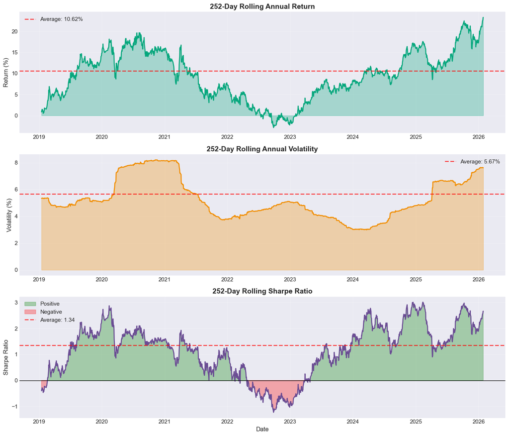

```python
# Calculate rolling metrics
window = 252  # 1-year rolling window

rolling_return = returns_series.rolling(window).mean() * 252 * 100
rolling_vol = returns_series.rolling(window).std() * np.sqrt(252) * 100
rolling_sharpe = (rolling_return - 3) / rolling_vol  # Assuming 3% risk-free rate

# Create visualization
fig, (ax1, ax2, ax3) = plt.subplots(3, 1, figsize=(14, 12))

# Rolling return
ax1.plot(rolling_return.index, rolling_return.values, linewidth=2, color='#06A77D')
ax1.fill_between(rolling_return.index, 0, rolling_return.values, alpha=0.3, color='#06A77D')
ax1.axhline(y=metrics['annual_return'] * 100, color='red', linestyle='--',
           linewidth=2, label=f'Average: {metrics["annual_return"]:.2%}', alpha=0.7)
ax1.set_title('252-Day Rolling Annual Return', fontsize=14, fontweight='bold')
ax1.set_ylabel('Return (%)', fontsize=12)
ax1.legend(fontsize=11)
ax1.grid(True, alpha=0.3)

# Rolling volatility
ax2.plot(rolling_vol.index, rolling_vol.values, linewidth=2, color='#F18F01')
ax2.fill_between(rolling_vol.index, 0, rolling_vol.values, alpha=0.3, color='#F18F01')
ax2.axhline(y=metrics['annual_volatility'] * 100, color='red', linestyle='--',
           linewidth=2, label=f'Average: {metrics["annual_volatility"]:.2%}', alpha=0.7)
ax2.set_title('252-Day Rolling Annual Volatility', fontsize=14, fontweight='bold')
ax2.set_ylabel('Volatility (%)', fontsize=12)
ax2.legend(fontsize=11)
ax2.grid(True, alpha=0.3)

# Rolling Sharpe ratio
ax3.plot(rolling_sharpe.index, rolling_sharpe.values, linewidth=2, color='#6A4C93')
ax3.fill_between(rolling_sharpe.index, 0, rolling_sharpe.values,
                where=(rolling_sharpe > 0), alpha=0.3, color='green', label='Positive')
ax3.fill_between(rolling_sharpe.index, 0, rolling_sharpe.values,
                where=(rolling_sharpe <= 0), alpha=0.3, color='red', label='Negative')
ax3.axhline(y=metrics['sharpe_ratio'], color='red', linestyle='--',
           linewidth=2, label=f'Average: {metrics["sharpe_ratio"]:.2f}', alpha=0.7)
ax3.axhline(y=0, color='black', linewidth=1)
ax3.set_title('252-Day Rolling Sharpe Ratio', fontsize=14, fontweight='bold')
ax3.set_ylabel('Sharpe Ratio', fontsize=12)
ax3.set_xlabel('Date', fontsize=12)
ax3.legend(fontsize=11)
ax3.grid(True, alpha=0.3)

plt.tight_layout()
plt.show()
```

### 8.2 Return Distribution Analysis

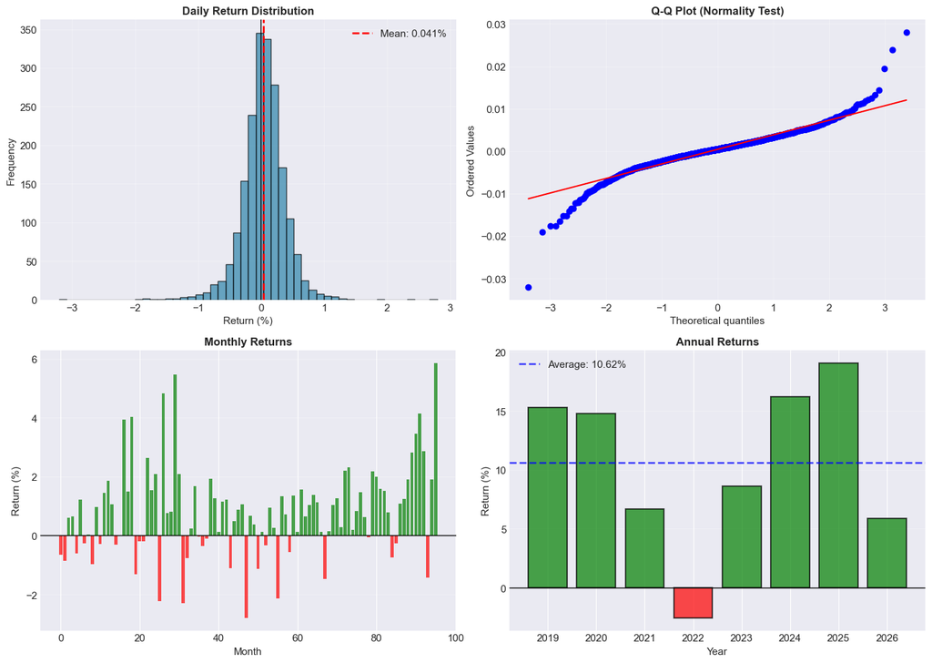

```
Return Distribution Statistics:
======================================================================
Daily Returns:
  Mean: 0.0407%
  Median: 0.0453%
  Std: 0.3569%
  Skewness: -0.423 (Left-skewed)
  Kurtosis: 8.739 (Fat tails)

Monthly Returns:
  Mean: 0.83%
  Best: 5.85%
  Worst: -2.79%
  Positive Months: 69/96 (71.9%)

Annual Returns:
  Mean: 10.50%
  Best: 19.05%
  Worst: -2.54%
  Positive Years: 7/8
```

```python
# Analyze return distribution
fig, ((ax1, ax2), (ax3, ax4)) = plt.subplots(2, 2, figsize=(14, 10))

# Histogram
ax1.hist(returns_series * 100, bins=50, alpha=0.7, color='#2E86AB', edgecolor='black')
ax1.axvline(x=returns_series.mean() * 100, color='red', linestyle='--',
           linewidth=2, label=f'Mean: {returns_series.mean()*100:.3f}%')
ax1.axvline(x=0, color='black', linewidth=1)
ax1.set_title('Daily Return Distribution', fontsize=12, fontweight='bold')
ax1.set_xlabel('Return (%)')
ax1.set_ylabel('Frequency')
ax1.legend()
ax1.grid(True, alpha=0.3)

# Q-Q plot (normality test)
from scipy import stats
stats.probplot(returns_series, dist="norm", plot=ax2)
ax2.set_title('Q-Q Plot (Normality Test)', fontsize=12, fontweight='bold')
ax2.grid(True, alpha=0.3)

# Monthly returns
monthly_returns = equity_curve.resample('ME').last().pct_change().dropna() * 100
colors = ['green' if x > 0 else 'red' for x in monthly_returns]
ax3.bar(range(len(monthly_returns)), monthly_returns.values, color=colors, alpha=0.7)
ax3.axhline(y=0, color='black', linewidth=1)
ax3.set_title('Monthly Returns', fontsize=12, fontweight='bold')
ax3.set_xlabel('Month')
ax3.set_ylabel('Return (%)')
ax3.grid(True, alpha=0.3, axis='y')

# Annual returns
annual_returns = equity_curve.resample('YE').last().pct_change().dropna() * 100
colors = ['green' if x > 0 else 'red' for x in annual_returns]
years = [d.year for d in annual_returns.index]
ax4.bar(years, annual_returns.values, color=colors, alpha=0.7, edgecolor='black', linewidth=1.5)
ax4.axhline(y=0, color='black', linewidth=1)
ax4.axhline(y=metrics['annual_return'] * 100, color='blue', linestyle='--',
           linewidth=2, label=f'Average: {metrics["annual_return"]:.2%}', alpha=0.7)
ax4.set_title('Annual Returns', fontsize=12, fontweight='bold')
ax4.set_xlabel('Year')
ax4.set_ylabel('Return (%)')
ax4.legend()
ax4.grid(True, alpha=0.3, axis='y')

plt.tight_layout()
plt.show()

# Print distribution statistics
print("\nReturn Distribution Statistics:")
print("=" * 70)
print(f"Daily Returns:")
print(f"  Mean: {returns_series.mean()*100:.4f}%")
print(f"  Median: {returns_series.median()*100:.4f}%")
print(f"  Std: {returns_series.std()*100:.4f}%")
print(f"  Skewness: {metrics['skewness']:.3f} ({'Left-skewed' if metrics['skewness'] < 0 else 'Right-skewed'})")
print(f"  Kurtosis: {metrics['kurtosis']:.3f} ({'Fat tails' if metrics['kurtosis'] > 0 else 'Thin tails'})")
print(f"\nMonthly Returns:")
print(f"  Mean: {monthly_returns.mean():.2f}%")
print(f"  Best: {monthly_returns.max():.2f}%")
print(f"  Worst: {monthly_returns.min():.2f}%")
print(f"  Positive Months: {(monthly_returns > 0).sum()}/{len(monthly_returns)} ({(monthly_returns > 0).mean():.1%})")
print(f"\nAnnual Returns:")
print(f"  Mean: {annual_returns.mean():.2f}%")
print(f"  Best: {annual_returns.max():.2f}%")
print(f"  Worst: {annual_returns.min():.2f}%")
print(f"  Positive Years: {(annual_returns > 0).sum()}/{len(annual_returns)}")
```

### 8.3 Rebalancing Activity Analysis

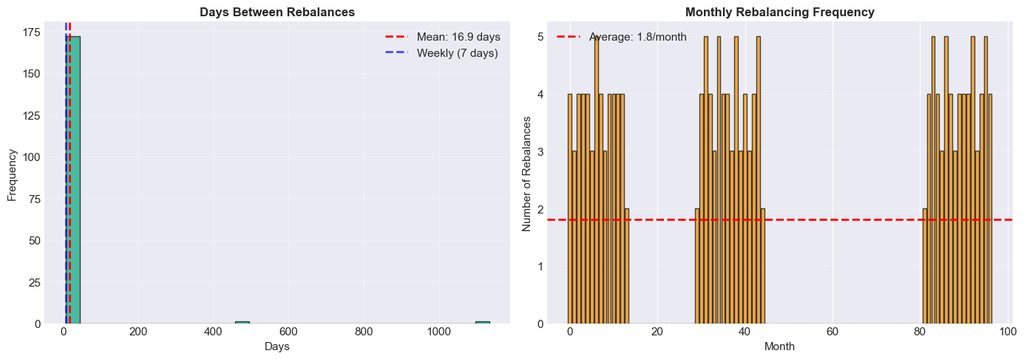

```
Rebalancing Statistics:
======================================================================
Total Rebalances: 175
Total Skipped: 209
Efficiency: 50.5%

Days Between Rebalances:
  Mean: 16.9 days
  Median: 7.0 days
  Min: 7 days
  Max: 1134 days
```

```python
# Analyze rebalancing patterns
if not weights_history.empty:
    # Calculate time between rebalances
    rebal_dates = weights_history.index
    days_between = [(rebal_dates[i+1] - rebal_dates[i]).days
                    for i in range(len(rebal_dates)-1)]

    # Create visualization
    fig, (ax1, ax2) = plt.subplots(1, 2, figsize=(14, 5))

    # Days between rebalances
    ax1.hist(days_between, bins=30, alpha=0.7, color='#06A77D', edgecolor='black')
    ax1.axvline(x=np.mean(days_between), color='red', linestyle='--',
               linewidth=2, label=f'Mean: {np.mean(days_between):.1f} days')
    ax1.axvline(x=7, color='blue', linestyle='--',
               linewidth=2, label='Weekly (7 days)', alpha=0.7)
    ax1.set_title('Days Between Rebalances', fontsize=12, fontweight='bold')
    ax1.set_xlabel('Days')
    ax1.set_ylabel('Frequency')
    ax1.legend()
    ax1.grid(True, alpha=0.3)

    # Rebalances over time
    rebal_counts = pd.Series(1, index=rebal_dates).resample('ME').sum()
    ax2.bar(range(len(rebal_counts)), rebal_counts.values, alpha=0.7,
           color='#F18F01', edgecolor='black')
    ax2.axhline(y=rebal_counts.mean(), color='red', linestyle='--',
               linewidth=2, label=f'Average: {rebal_counts.mean():.1f}/month')
    ax2.set_title('Monthly Rebalancing Frequency', fontsize=12, fontweight='bold')
    ax2.set_xlabel('Month')
    ax2.set_ylabel('Number of Rebalances')
    ax2.legend()
    ax2.grid(True, alpha=0.3, axis='y')

    plt.tight_layout()
    plt.show()

    # Print statistics
    print("\nRebalancing Statistics:")
    print("=" * 70)
    print(f"Total Rebalances: {results['rebalances_executed']}")
    print(f"Total Skipped: {results['rebalances_skipped']}")
    print(f"Efficiency: {results['rebalance_efficiency']:.1%}")
    print(f"\nDays Between Rebalances:")
    print(f"  Mean: {np.mean(days_between):.1f} days")
    print(f"  Median: {np.median(days_between):.1f} days")
    print(f"  Min: {np.min(days_between)} days")
    print(f"  Max: {np.max(days_between)} days")
```

## 9. Conclusions and Extensions

### 9.1 Key Findings

**Performance Summary** (2018-2026):

- **Total Return**: 119.15% (¥1M → ¥2.19M)
- **Annual Return**: 10.62%
- **Sharpe Ratio**: 1.34
- **Max Drawdown**: -7.68%

### 9.2 Comparison with Alternatives

| Strategy | Return | Sharpe | Max DD | Key Feature |
| --- | --- | --- | --- | --- |
| **v1.2** | **10.62%** | **1.34** | -7.68% | Shrinkage + Adaptive |
| v1.1 | 7.58% | 1.13 | -6.55% | Adaptive only |
| v1.0 | 7.05% | 1.11 | -3.90% | Pure baseline |
| 60/40 | ~8-9% | ~0.8-1.0 | -15-20% | Traditional |

**v1.2 Advantages**:

- Higher risk-adjusted returns (Sharpe 1.34 vs 0.8-1.0)
- Controlled drawdowns (max -7.68% vs -15-20%)
- No return forecasts required
- Robust to regime changes

### 9.3 Practical Considerations

**Implementation Requirements**:

1. **Data**: 252+ days of historical prices (1 year minimum)
2. **Rebalancing**: Weekly Monday recommended
3. **Threshold**: 5% drift optimal for this universe
4. **Costs**: 0.03% commission assumed (adjust for your broker)

**When to Use v1.2**:

- ✓ Long-term investment horizon (>5 years)
- ✓ Want stable, all-weather performance
- ✓ Willing to accept lower returns for lower risk
- ✓ Can tolerate high bond allocation

**When NOT to Use**:

- ✗ Short-term trading (<1 year)
- ✗ Seeking maximum returns (use concentrated equity)
- ✗ Cannot access bonds/commodities
- ✗ High transaction costs (>0.1%)

### 9.4 Extensions and Future Work

**Potential Improvements**:

1. **Dynamic Shrinkage**: Adjust δ based on market conditions

   ```
   # Higher shrinkage during high volatility
   delta = min(0.5, base_delta * (current_vol / long_term_vol))
   ```

2. **Adaptive Threshold**: Adjust drift threshold based on market regime

   ```
   # Lower threshold (more rebalancing) during trending markets
   threshold = base_threshold * (1 + trend_strength)
   ```

3. **Volatility Targeting**: Scale portfolio to target risk level

   ```
   # Scale weights to achieve 6% annual volatility
   scaled_weights = apply_volatility_target(weights, cov, target_vol=0.06)
   ```

4. **Factor Risk Parity**: Equal contribution from economic factors
   - Growth, inflation, rates, credit, etc.
   - More granular than asset-level risk parity
5. **Machine Learning**: Predict optimal shrinkage/threshold parameters
   - Train on historical data
   - Adaptive to market conditions

### 9.5 References

**Academic Papers**:

1. Ledoit, O. & Wolf, M. (2004). "A well-conditioned estimator for large-dimensional covariance matrices"
2. Maillard, S., Roncalli, T., & Teïletche, J. (2010). "The properties of equally weighted risk contribution portfolios"
3. Asness, C., Frazzini, A., & Pedersen, L. (2012). "Leverage aversion and risk parity"
4. Bruder, B. & Roncalli, T. (2012). "Managing risk exposures using the risk budgeting approach"

**Practitioner Resources**:

- Dalio, R. "Engineering Targeted Returns and Risks" (Bridgewater Associates)
- Qian, E. (2005). "Risk parity portfolios: Efficient portfolios through true diversification"
- Anderson, R. et al. (2012). "Risk parity" (MSCI Research)

**Code References**:

- `src/optimizer.py`: Core optimization algorithms
- `src/strategy.py`: Strategy implementation
- `src/portfolio.py`: Portfolio management
- `CLAUDE.md`: Full project documentation

## Appendix: Quick Reference

### A.1 Key Formulas

**Euler Formula**:

$f(w)$ is homogeneous of degree $k$ means $f(\lambda w)=\lambda^k w, \forall \lambda>0$

$f(w)$ is homogeneous of degree $k$, then $$kf(w)=\sum_{i=1}^n w_i\frac{\partial f(w_i)}{\partial w_i}$$

**Risk Contribution**: $$RC_i = w_i \cdot \frac{(\Sigma w)_i}{\sqrt{w^T \Sigma w}}$$

**Risk Parity Objective**: $$\min_w \text{std}(RC_1, \ldots, RC_n) \quad \text{s.t.} \quad \sum w_i = 1, \; w_i \geq 0$$

**Ledoit-Wolf Shrinkage**: $$\Sigma_{\text{shrunk}} = (1-\delta) \hat{\Sigma} + \delta F$$

**Drift Condition**: $$\text{Rebalance} \iff \max_i |w_i^{\text{current}} - w_i^{\text{target}}| > \theta$$

### A.2 Configuration Template

```
from src.strategy import AllWeatherV1
from src.data_loader import load_prices

# Load data
prices = load_prices('data/etf_prices_7etf.csv')

# Initialize v1.2 strategy
strategy = AllWeatherV1(
    prices=prices,
    initial_capital=1_000_000,    # ¥1M
    rebalance_freq='W-MON',       # Weekly Monday
    lookback=252,                 # 1 year
    commission_rate=0.0003,       # 0.03%
    rebalance_threshold=0.05,     # 5% drift
    use_shrinkage=True            # Ledoit-Wolf
)

# Run backtest
results = strategy.run_backtest(
    start_date='2018-01-01',
    verbose=True
)

# Access results
print(f"Final Value: ¥{results['final_value']:,.0f}")
print(f"Annual Return: {results['metrics']['annual_return']:.2%}")
print(f"Sharpe Ratio: {results['metrics']['sharpe_ratio']:.2f}")
```

### A.3 Performance Benchmarks

**Expected Results** (2018-2026, ¥1M initial):

- Final Value: ¥2,191,500 (±5%)
- Annual Return: 10.62% (±0.5%)
- Sharpe Ratio: 1.34 (±0.1)
- Max Drawdown: -7.68% (±1%)
- Rebalances: 175 (±20)

**If your results differ significantly**:

1. Check data quality (no missing/frozen prices)
2. Verify commission rate (0.03%)
3. Confirm lookback window (252 days)
4. Ensure shrinkage is enabled
5. Check drift threshold (5%)